# 3. Analysis Plan

Analyze and compare data

Hauke Roggenkamp https://github.com/Howquez (CLICCS)https://www.cliccs.uni-hamburg.de/  
2022-10-29

```r
knitr::opts_chunk$set(echo = TRUE)

library(data.table)
library(magrittr)
library(kableExtra)
library(downloadthis)
library(ggplot2)
library(patchwork)
library(stargazer)
```

# Background

[This report](https://github.com/Howquez/coopUncertainty/blob/July21Replication/analysis/reports/rmd/03_dataAnalyses.Rmd) is the third in a series of reports covering this project. It reads the data prepared in the previous reports and analyzes them.

```r
base::load(file="../../../data/processed/rda/GMTV2017.rda")              # read GMTV
base::load(file="../../../data/processed/rda/GMTV2017_R1.rda")           # read GMTVFirstRound
base::load(file="../../../data/processed/rda/GMTV2017_COVS.rda")         # read GMTVCovariates
base::load(file="../../../data/processed/rda/replication2021.rda")       # read replication
base::load(file="../../../data/processed/rda/replication2021_R1.rda")    # read replicationFirstRound
base::load(file="../../../data/processed/rda/replication2021_COVS.rda")  # read replicationCovariates
```

```r
main <- rbindlist(list(replication, GMTV),
                  use.names = TRUE)

R1   <- rbindlist(list(replicationFirstRound, GMTVFirstRound),
                  use.names = TRUE)

covs <- rbindlist(list(replicationCovariates, GMTVCovariates),
                  use.names = TRUE,
                  fill = TRUE)

rm(list = c("replication", "GMTV", "replicationFirstRound", "GMTVFirstRound", "GMTVCovariates", "replicationCovariates"))
```

# Results

```r
layout <- theme(panel.background = element_rect(fill = "white"),
                panel.grid = element_blank(),
                panel.grid.major.y = element_line(colour="gray", size=0.25),
                legend.key = element_rect(fill = "white"),
                axis.line.x.bottom = element_line(size = 0.25),
                axis.line.y.left = element_line(size = 0.25),
                axis.title.y = element_text(size = rel(0.75)),
                plot.margin = unit(c(0.25,0.25,0.25,0.25), "cm"),
                legend.title = element_blank()
                )

colors <- c("#F3B05C", "#1E4A75", "#65B5C0", "#AD5E21")
```

## First Round

```r
ggplot(R1, aes(y=ownContribution, x=othersContribution/3)) +
  layout +
  geom_abline(intercept = 0, slope = 1, linetype="dashed", alpha = 0.66) +
  geom_point(color = colors) +
  scale_y_continuous(expand = c(0, 0), limits = c(-1, 25)) +
  scale_x_continuous(expand = c(0, 0), limits = c(-1, 25))
```

[output not shown]

## Provision of the public good and wealth creation

```r
SUM <- main[,
            lapply(.SD, mean, na.rm = TRUE),
            by = c("round", "treatment"),
            .SDcols = "contribution"]

SUM[,
    sum := round(contribution/4)]

upperLimit <- SUM$contribution %>% max() %>% round() + 10

p1 <- ggplot(data = SUM,
             aes(x = round, y = contribution, fill = treatment, color = treatment, lty = treatment)) +
  layout +
  theme(legend.position="bottom") +
  geom_line(show.legend=FALSE) +
  geom_point() +
  scale_x_continuous(name="",  breaks = 1:15) +
  scale_y_continuous(limits = c(0, upperLimit), expand = c(0, 0)) +
  labs(y = "Average Amount of Tokens contributed") +
  scale_color_manual(values = colors) +
  theme(plot.margin = margin(0.25,1,0.25,0.25, "cm"))

rm(list = c("SUM"))
```

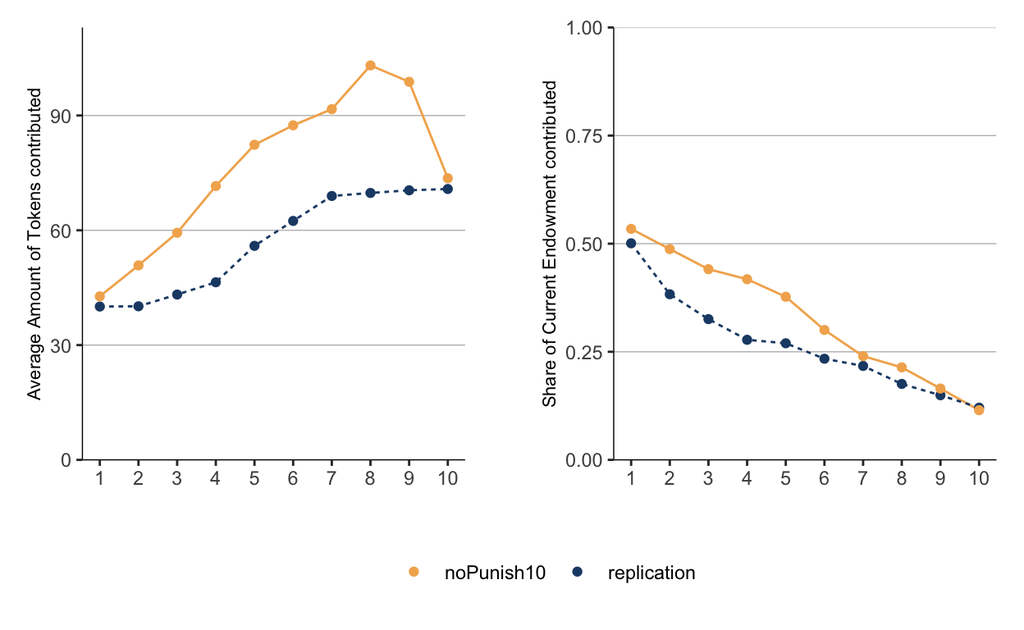

Figure 1: The average amount of tokens contributed over time in treatments.

```r
SHARE <- main[,
            lapply(.SD, mean, na.rm = TRUE),
            by = c("round", "treatment"),
            .SDcols = "share"]

upperLimit <- 1

p2 <- ggplot(data = SHARE,
             aes(x = round, y = share, fill = treatment, color = treatment, lty = treatment)) +
  layout +
  theme(legend.position="bottom") +
  geom_line(show.legend=FALSE) +
  geom_point() +
  scale_x_continuous(name="",  breaks = 1:15) +
  scale_y_continuous(limits = c(0, upperLimit), expand = c(0, 0)) +
  labs(y = "Share of Current Endowment contributed") +
  scale_color_manual(values = colors)

p1 + p2 + plot_layout(guides = "collect") & theme(legend.position = "bottom")
```

```r
rm(list = c("SHARE", "p1", "p2"))
```

```r
if(knitr::is_html_output()){
  type <- "html"
} else {
  type = "latex"
}

replication <- main[treatment == "replication" & round == 10, stock]
GMTV    <- main[treatment == "noPunish10" & round == 10, stock]


rows <- sapply(X = list(replication, GMTV), FUN = NROW) %>% max()
temp <- data.frame(replication = c(replication, rep(NA, rows - NROW(replication))),
                   GMTV = c(GMTV, rep(NA, rows - NROW(GMTV))))

stargazer(temp,
          summary.stat = c("mean", "median","sd", "max", "min", "n"),
          type = type,
          flip = TRUE,
          header=FALSE)
```

| Statistic | replication | GMTV |
| --- | --- | --- |
| Mean | 379.828 | 478.087 |
| Median | 262 | 304 |
| St. Dev. | 336.059 | 393.575 |
| Max | 1,425 | 1,792 |
| Min | 92 | 161 |
| N | 29 | 23 |

```r
rs1 <- wilcox.test(replication,
                   GMTV,
                   exact = FALSE)$p.value %>%
  round(digits = 4) %>%
  formatC(format = "f",
          digits = 4)
```

The rank sum test yields a p-Value of 0.1356 for the mean `stock` a.k.a *Wealth* during the last period of the game.

```r
# create subsets
main_all  <- main[round == 10]
main_poor <- main[round == 10 & rich == FALSE]
main_rich <- main[round == 10 & rich == TRUE]

# create table
if(knitr::is_html_output()){
  type <- "html"
} else {
  type = "latex"
}

m1 <- lm(formula = stock ~ treatment, data = main_all)
m2 <- lm(formula = stock ~ treatment, data = main_poor)
m3 <- lm(formula = stock ~ treatment, data = main_rich)

stargazer(m1, m2, m3,

          column.labels = c("All", "Below median", "Above median"),
          model.numbers = FALSE,
          dep.var.labels = "Wealth",
          header=FALSE,
          covariate.labels = c("Replication"),

          type = type, digits = 2, omit.stat = c("adj.rsq", "f"), df = FALSE
          )
```

|  | *Dependent variable:* |  |  |
| --- | --- | --- | --- |
|  | Wealth |  |  |
|  | All | Below median | Above median |
| Replication | -98.26 | -59.41*** | -138.21 |
|  | (101.21) | (18.32) | (166.67) |
| Constant | 478.09*** | 234.70*** | 731.00*** |
|  | (75.58) | (13.99) | (124.73) |
| Observations | 52 | 24 | 25 |
| R<sup>2</sup> | 0.02 | 0.32 | 0.03 |
| Residual Std. Error | 362.49 | 44.24 | 413.67 |
| *Note:* | p<0.1; p<0.05; p<0.01 |  |  |

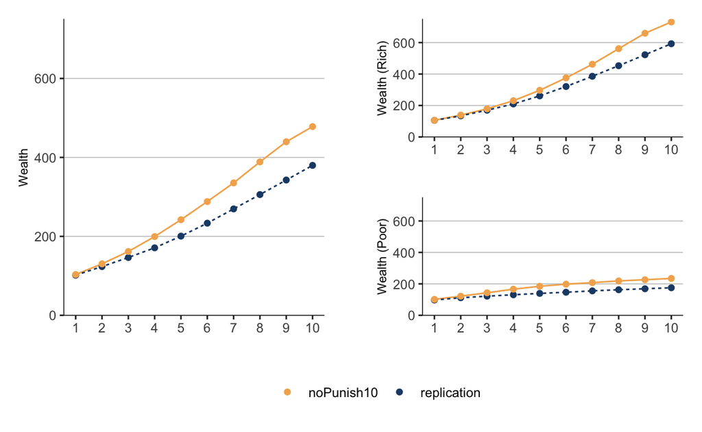

Figure 2: Average wealth over time across treatments.

```r
STOCK <- main[,
              lapply(.SD, mean, na.rm = TRUE),
              by = c("round", "treatment"),
              .SDcols = "stock"]

STOCKr <- main[rich == TRUE,
               lapply(.SD, mean, na.rm = TRUE),
               by = c("round", "treatment"),
               .SDcols = "stock"]

STOCKp <- main[rich == FALSE,
               lapply(.SD, mean, na.rm = TRUE),
               by = c("round", "treatment"),
               .SDcols = "stock"]

upperLimit <- STOCKr$stock %>% max() %>% round() + 20

p1 <- ggplot(data = STOCK,
       aes(x = round, y = stock, fill = treatment, color = treatment, lty = treatment)) +
          layout +
          theme(legend.position="bottom") +
          # geom_vline(xintercept = 10, alpha = 0.66) +
          geom_line(show.legend=FALSE) +
          geom_point() +
          scale_x_continuous(name="",  breaks = 1:10) +
          scale_y_continuous(limits = c(0, upperLimit), expand = c(0, 0)) +
          labs(y = "Wealth") +
          scale_color_manual(values = colors) +
          theme(plot.margin = margin(0.25,1,0.25,0.25, "cm"))

p2 <- ggplot(data = STOCKr,
       aes(x = round, y = stock, fill = treatment, color = treatment, lty = treatment)) +
          layout +
          theme(legend.position="bottom") +
          # geom_vline(xintercept = 10, alpha = 0.66) +
          geom_line(show.legend=FALSE) +
          geom_point() +
          scale_x_continuous(name="",  breaks = 1:10) +
          scale_y_continuous(limits = c(0, upperLimit), expand = c(0, 0)) +
          labs(y = "Wealth (Rich)") +
          scale_color_manual(values = colors)

p3 <- ggplot(data = STOCKp,
       aes(x = round, y = stock, fill = treatment, color = treatment, lty = treatment)) +
          layout +
          theme(legend.position="bottom") +
          # geom_vline(xintercept = 10, alpha = 0.66) +
          geom_line(show.legend=FALSE) +
          geom_point() +
          scale_x_continuous(name="",  breaks = 1:10) +
          scale_y_continuous(limits = c(0, upperLimit), expand = c(0, 0)) +
          labs(y = "Wealth (Poor)") +
          scale_color_manual(values = colors)

(p1 | (p2 / p3)) + plot_layout(guides = "collect") & theme(legend.position = "bottom")
```

```r
rm(list = c("STOCK", "STOCKr", "STOCKp", "p1", "p2", "p3"))
```

## Inequality

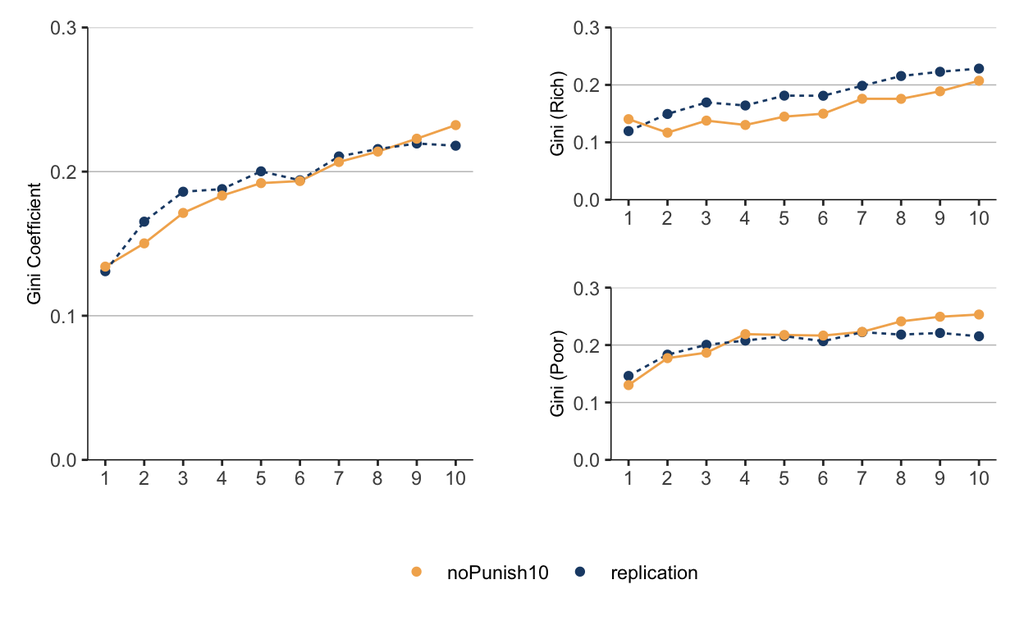

Figure 3: Average Gini coefficient over time across treatments.

```r
GINI <- main[,
             lapply(.SD, mean, na.rm = TRUE),
             by = c("round", "treatment"),
             .SDcols = "gini"]

GINIr <- main[rich == TRUE,
              lapply(.SD, mean, na.rm = TRUE),
              by = c("round", "treatment"),
              .SDcols = "gini"]

GINIp <- main[rich == FALSE,
              lapply(.SD, mean, na.rm = TRUE),
              by = c("round", "treatment"),
              .SDcols = "gini"]

upperLimit <- GINI$gini %>% max() %>% round(digits = 1) + 0.10

p1 <- ggplot(data = GINI,
       aes(x = round, y = gini, fill = treatment, color = treatment, lty = treatment)) +
          layout +
          theme(legend.position="bottom") +
          # geom_vline(xintercept = 10, alpha = 0.66) +
          geom_line(show.legend=FALSE) +
          geom_point() +
          scale_x_continuous(name="",  breaks = 1:10) +
          scale_y_continuous(limits = c(0, upperLimit), expand = c(0, 0)) +
          labs(y = "Gini Coefficient") +
          scale_color_manual(values = colors) +
          theme(plot.margin = margin(0.25,1,0.25,0.25, "cm"))

p2 <- ggplot(data = GINIr,
       aes(x = round, y = gini, fill = treatment, color = treatment, lty = treatment)) +
          layout +
          theme(legend.position="bottom") +
          # geom_vline(xintercept = 10, alpha = 0.66) +
          geom_line(show.legend=FALSE) +
          geom_point() +
          scale_x_continuous(name="",  breaks = 1:10) +
          scale_y_continuous(limits = c(0, upperLimit), expand = c(0, 0)) +
          labs(y = "Gini (Rich)") +
          scale_color_manual(values = colors)

p3 <- ggplot(data = GINIp,
       aes(x = round, y = gini, fill = treatment, color = treatment, lty = treatment)) +
          layout +
          theme(legend.position="bottom") +
          # geom_vline(xintercept = 10, alpha = 0.66) +
          geom_line(show.legend=FALSE) +
          geom_point() +
          scale_x_continuous(name="",  breaks = 1:10) +
          scale_y_continuous(limits = c(0, upperLimit), expand = c(0, 0)) +
          labs(y = "Gini (Poor)") +
          scale_color_manual(values = colors)

(p1 | (p2 / p3)) + plot_layout(guides = "collect") & theme(legend.position = "bottom")
```

```r
rm(list = c("GINI", "GINIp", "GINIr", "p1", "p2", "p3"))
```

```r
# create subsets
main_all  <- main[round == 10]
main_poor <- main[round == 10 & rich == FALSE]
main_rich <- main[round == 10 & rich == TRUE]

# create table
if(knitr::is_html_output()){
  type <- "html"
} else {
  type = "latex"
}

m1 <- lm(formula = gini ~ treatment, data = main_all)
m2 <- lm(formula = gini ~ treatment, data = main_poor)
m3 <- lm(formula = gini ~ treatment, data = main_rich)
stargazer(m1, m2, m3,

          column.labels = c("All", "Below median", "Above median"),
          model.numbers = FALSE,
          dep.var.labels = "Gini",
          header=FALSE,
          covariate.labels = c("Replication"),

          type = type, digits = 2, omit.stat = c("adj.rsq", "f"), df = FALSE
          )
```

|  | *Dependent variable:* |  |  |
| --- | --- | --- | --- |
|  | Gini |  |  |
|  | All | Below median | Above median |
| Replication | -0.01 | -0.04 | 0.02 |
|  | (0.03) | (0.05) | (0.05) |
| Constant | 0.23*** | 0.25*** | 0.21*** |
|  | (0.03) | (0.04) | (0.04) |
| Observations | 52 | 24 | 25 |
| R<sup>2</sup> | 0.003 | 0.02 | 0.01 |
| Residual Std. Error | 0.12 | 0.13 | 0.12 |
| *Note:* | p<0.1; p<0.05; p<0.01 |  |  |

```r
if(knitr::is_html_output()){
  type <- "html"
} else {
  type = "latex"
}

replication <- main[treatment == "replication" & round == 10, gini]
GMTV    <- main[treatment == "noPunish10" & round == 10, gini]


rows <- sapply(X = list(replication, GMTV), FUN = NROW) %>% max()
temp <- data.frame(replication = c(replication, rep(NA, rows - NROW(replication))),
                   GMTV = c(GMTV, rep(NA, rows - NROW(GMTV))))

stargazer(temp,
          summary.stat = c("mean", "median","sd", "max", "min", "n"),
          type = type,
          flip = TRUE,
          header=FALSE)
```

| Statistic | replication | GMTV |
| --- | --- | --- |
| Mean | 0.218 | 0.232 |
| Median | 0.218 | 0.233 |
| St. Dev. | 0.123 | 0.123 |
| Max | 0.520 | 0.423 |
| Min | 0.035 | 0.040 |
| N | 29 | 23 |

```r
rs2 <- wilcox.test(replication,
                   GMTV,
                   exact = FALSE)$p.value %>%
  round(digits = 4) %>%
  formatC(format = "f",
          digits = 4)
```

The rank sum test yields a p-Value of 0.6059 for the mean `gini` during the last period of the game.

## Sample Properties

```r
covariates <- data.table::merge.data.table(x  = covs,
                                           y  = main[round == 10, .(groupID, stock, gini)],
                                           by = c("groupID"),
                                           allow.cartesian = TRUE)

covariates[,
           gender := gender %>% as.numeric()]
```

In addition to the summary statistics a regression table for each covariate as a dependent variable is needed. The independent variable will then be the data source (i.e. GMTV vs replication).

```r
# create table
if(knitr::is_html_output()){
  type <- "html"
} else {
  type = "latex"
}

temp <- covariates[treatment == "replication",
                   .(gender, age, switching_row, education, donation, pq01, pq02, pq03, pq04,
                     pq05, pq06, pq07, pq08, pq09, pq10, pq11, pq12, pq13, pq14)]
stargazer(temp, type = type, flip = FALSE)
```

| Statistic | N | Mean | St. Dev. | Min | Max |
| --- | --- | --- | --- | --- | --- |
| gender | 116 | 0.526 | 0.501 | 0 | 1 |
| age | 116 | 35.767 | 15.663 | 9 | 73 |
| switching_row | 78 | 6.154 | 2.151 | 1 | 12 |
| education | 116 | 6.241 | 0.966 | 3 | 8 |
| donation | 116 | 0.931 | 1.672 | 0.000 | 11.050 |
| pq01 | 116 | 4.302 | 1.144 | 1 | 6 |
| pq02 | 116 | 2.681 | 1.702 | 0 | 6 |
| pq03 | 116 | 3.759 | 1.184 | 1 | 6 |
| pq04 | 116 | 1.853 | 1.551 | 0 | 6 |
| pq05 | 116 | 4.284 | 1.207 | 1 | 6 |
| pq06 | 116 | 3.672 | 1.525 | 0 | 6 |
| pq07 | 116 | 4.879 | 1.463 | 0 | 6 |
| pq08 | 116 | 4.647 | 1.385 | 1 | 6 |
| pq09 | 116 | 1.560 | 2.006 | 0 | 6 |
| pq10 | 116 | 3.009 | 1.639 | 0 | 6 |
| pq11 | 116 | 3.586 | 1.358 | 0 | 6 |
| pq12 | 116 | 3.914 | 1.564 | 0 | 6 |
| pq13 | 116 | 3.836 | 1.480 | 0 | 6 |
| pq14 | 116 | 4.241 | 1.618 | 0 | 6 |

```r
# create table
if(knitr::is_html_output()){
  type <- "html"
} else {
  type = "latex"
}

m1 <- lm(formula = gender ~ treatment, data = covs)
m2 <- lm(formula = age ~ treatment, data = covs)
m3 <- lm(formula = switching_row ~ treatment, data = covs)
m4 <- lm(formula = donation ~ treatment, data = covs)

stargazer(m1, m2, m3, m4,

          column.labels = c("female", "age", "risk", "donations"),
          model.numbers = FALSE,
          dep.var.labels.include = FALSE,
          header=FALSE,
          covariate.labels = c("Replication"),

          type = type, digits = 2, omit.stat = c("adj.rsq", "f"), df = FALSE
          )
```

|  | *Dependent variable:* |  |  |  |
| --- | --- | --- | --- | --- |
|  | female | age | risk | donations |
| Replication | 0.15** | 4.04** | -0.28 | 0.25 |
|  | (0.07) | (1.65) | (0.27) | (0.23) |
| Constant | 0.38*** | 31.73*** | 6.44*** | 0.68*** |
|  | (0.05) | (1.23) | (0.19) | (0.17) |
| Observations | 208 | 208 | 165 | 208 |
| R<sup>2</sup> | 0.02 | 0.03 | 0.01 | 0.01 |
| Residual Std. Error | 0.50 | 11.83 | 1.76 | 1.66 |
| *Note:* | p<0.1; p<0.05; p<0.01 |  |  |  |

```r
# create table
if(knitr::is_html_output()){
  type <- "html"
} else {
  type = "latex"
}

m1 <- lm(formula = pq01 ~ treatment, data = covs)
m2 <- lm(formula = pq02 ~ treatment, data = covs)
m3 <- lm(formula = pq03 ~ treatment, data = covs)
m4 <- lm(formula = pq04 ~ treatment, data = covs)
m5 <- lm(formula = pq05 ~ treatment, data = covs)

stargazer(m1, m2, m3, m4, m5,

          column.labels = c("quick thinker", "easily offended", "very satisfied", "very dependent", "generally happy"),
          model.numbers = FALSE,
          dep.var.labels.include = FALSE,
          header=FALSE,
          covariate.labels = c("Replication"),

          type = type, digits = 2, omit.stat = c("adj.rsq", "f"), df = FALSE
          )
```

|  | *Dependent variable:* |  |  |  |  |
| --- | --- | --- | --- | --- | --- |
|  | quick thinker | easily offended | very satisfied | very dependent | generally happy |
| Replication | -0.77*** | -1.03*** | -1.23*** | -0.94*** | -1.36*** |
|  | (0.17) | (0.23) | (0.17) | (0.20) | (0.16) |
| Constant | 5.08*** | 3.71*** | 4.99*** | 2.79*** | 5.64*** |
|  | (0.13) | (0.17) | (0.13) | (0.15) | (0.12) |
| Observations | 208 | 208 | 208 | 208 | 208 |
| R<sup>2</sup> | 0.09 | 0.09 | 0.21 | 0.09 | 0.26 |
| Residual Std. Error | 1.20 | 1.66 | 1.21 | 1.46 | 1.15 |
| *Note:* | p<0.1; p<0.05; p<0.01 |  |  |  |  |

```r
# create table
if(knitr::is_html_output()){
  type <- "html"
} else {
  type = "latex"
}

m1 <- lm(formula = pq06 ~ treatment, data = covs)
m2 <- lm(formula = pq07 ~ treatment, data = covs)
m3 <- lm(formula = pq08 ~ treatment, data = covs)
m4 <- lm(formula = pq09 ~ treatment, data = covs)
m5 <- lm(formula = pq10 ~ treatment, data = covs)

stargazer(m1, m2, m3, m4, m5,

          column.labels = c("work important", "family important", "friends important", "religion important", "politics important"),
          model.numbers = FALSE,
          dep.var.labels.include = FALSE,
          header=FALSE,
          covariate.labels = c("Replication"),

          type = type, digits = 2, omit.stat = c("adj.rsq", "f"), df = FALSE
          )
```

|  | *Dependent variable:* |  |  |  |  |
| --- | --- | --- | --- | --- | --- |
|  | work important | family important | friends important | religion important | politics important |
| Replication | -1.04*** | -0.61*** | -1.30*** | -0.87*** | -0.69*** |
|  | (0.20) | (0.21) | (0.18) | (0.26) | (0.22) |
| Constant | 4.72*** | 5.49*** | 5.95*** | 2.43*** | 3.70*** |
|  | (0.15) | (0.16) | (0.13) | (0.20) | (0.16) |
| Observations | 208 | 208 | 208 | 208 | 208 |
| R<sup>2</sup> | 0.11 | 0.04 | 0.20 | 0.05 | 0.05 |
| Residual Std. Error | 1.46 | 1.51 | 1.28 | 1.88 | 1.58 |
| *Note:* | p<0.1; p<0.05; p<0.01 |  |  |  |  |

```r
# create table
if(knitr::is_html_output()){
  type <- "html"
} else {
  type = "latex"
}

m1 <- lm(formula = pq11 ~ treatment, data = covs)
m2 <- lm(formula = pq12 ~ treatment, data = covs)
m3 <- lm(formula = pq13 ~ treatment, data = covs)
m4 <- lm(formula = pq14 ~ treatment, data = covs)

stargazer(m1, m2, m3, m4,

          column.labels = c("most people trusted", "hard work better", "government responsible", "incomes equal"),
          model.numbers = FALSE,
          dep.var.labels.include = FALSE,
          header=FALSE,
          covariate.labels = c("Replication"),

          type = type, digits = 2, omit.stat = c("adj.rsq", "f"), df = FALSE
          )
```

|  | *Dependent variable:* |  |  |  |
| --- | --- | --- | --- | --- |
|  | most people trusted | hard work better | government responsible | incomes equal |
| Replication | -0.28 | -1.52*** | -0.48** | 0.42* |
|  | (0.19) | (0.21) | (0.20) | (0.23) |
| Constant | 3.87*** | 5.43*** | 4.32*** | 3.83*** |
|  | (0.14) | (0.16) | (0.15) | (0.17) |
| Observations | 208 | 208 | 208 | 208 |
| R<sup>2</sup> | 0.01 | 0.20 | 0.03 | 0.02 |
| Residual Std. Error | 1.36 | 1.52 | 1.42 | 1.63 |
| *Note:* | p<0.1; p<0.05; p<0.01 |  |  |  |

```r
# create table
if(knitr::is_html_output()){
  type <- "html"
} else {
  type = "latex"
}

olsStock1 <- lm(formula = stock ~ gender + age + switching_row + pq01 + pq02 + pq03 + pq04 +
                  pq05 + pq06 + pq07 +pq08 + pq09 + pq10 + pq11 + pq12 + pq13 + pq14,
                data = covariates[treatment == "replication"])
olsStock2  <- lm(formula = stock ~ gender + age + switching_row,
                data = covariates[treatment == "replication"])
olsGINI1  <- lm(formula = gini ~ gender + age + switching_row + pq01 + pq02 + pq03 + pq04 +
                  pq05 + pq06 + pq07 + pq08 + pq09 + pq10 + pq11 + pq12 + pq13 + pq14,
                data = covariates[treatment == "replication"])
olsGINI2  <- lm(formula = gini ~ gender + age + switching_row,
                data = covariates[treatment == "replication"])

stargazer(olsStock1, olsStock2,
          olsGINI1, olsGINI2,

          se = list(coef(summary(olsStock1, cluster = c("groupID")))[, 2],
                    coef(summary(olsStock2, cluster = c("groupID")))[, 2],
                    coef(summary(olsGINI1,  cluster = c("groupID")))[, 2],
                    coef(summary(olsGINI2,  cluster = c("groupID")))[, 2]),

          column.labels   = c("Wealth", "Gini"),
          dep.var.labels.include = FALSE,
          column.separate = c(2, 2),
          model.numbers = FALSE,
          header=FALSE,
          covariate.labels = c("female", "age", "risk",
                               "quick thinker",
                               "easily offended",
                               "very satisfied",
                               "very dependent",
                               "generally happy",
                               "work important",
                               "family important",
                               "friends important",
                               "religion important",
                               "politics important",
                               "most people trusted",
                               "hard work better",
                               "government responsible",
                               "incomes equal"),
          notes = "Robust standard errors in parentheses, clustered by group ID.",

          type = type, digits = 2, omit.stat = c("adj.rsq", "f"), df = FALSE
          )
```

|  | *Dependent variable:* |  |  |  |
| --- | --- | --- | --- | --- |
|  | Wealth |  | Gini |  |
| female | -30.63 | -65.02 | 0.02 | 0.02 |
|  | (88.07) | (83.80) | (0.03) | (0.03) |
| age | 7.05* | 9.00** | -0.001 | -0.001 |
|  | (3.82) | (3.60) | (0.001) | (0.001) |
| risk | 27.21 | 10.98 | -0.01 | -0.01 |
|  | (22.65) | (19.45) | (0.01) | (0.01) |
| quick thinker | -55.19 |  | 0.02 |  |
|  | (45.52) |  | (0.02) |  |
| easily offended | -26.52 |  | 0.01 |  |
|  | (31.48) |  | (0.01) |  |
| very satisfied | -2.62 |  | 0.001 |  |
|  | (42.60) |  | (0.02) |  |
| very dependent | -22.41 |  | 0.0003 |  |
|  | (30.47) |  | (0.01) |  |
| generally happy | 70.06 |  | 0.004 |  |
|  | (42.99) |  | (0.02) |  |
| work important | -64.01 |  | -0.01 |  |
|  | (39.13) |  | (0.02) |  |
| family important | 11.99 |  | -0.01 |  |
|  | (38.05) |  | (0.01) |  |
| friends important | -24.05 |  | -0.004 |  |
|  | (37.94) |  | (0.01) |  |
| religion important | -20.48 |  | 0.02* |  |
|  | (26.15) |  | (0.01) |  |
| politics important | 86.94*** |  | -0.01 |  |
|  | (30.79) |  | (0.01) |  |
| most people trusted | -0.49 |  | -0.001 |  |
|  | (31.94) |  | (0.01) |  |
| hard work better | 35.38 |  | -0.03* |  |
|  | (34.46) |  | (0.01) |  |
| government responsible | -47.38 |  | -0.03* |  |
|  | (39.54) |  | (0.02) |  |
| incomes equal | -9.13 |  | 0.01 |  |
|  | (33.79) |  | (0.01) |  |
| Constant | 278.16 | 100.12 | 0.39*** | 0.28*** |
|  | (377.35) | (180.67) | (0.14) | (0.07) |
| Observations | 78 | 78 | 78 | 78 |
| R<sup>2</sup> | 0.28 | 0.10 | 0.21 | 0.02 |
| Residual Std. Error | 357.69 | 360.58 | 0.14 | 0.14 |
| *Note:* | p<0.1; p<0.05; p<0.01 |  |  |  |
|  | Robust standard errors in parentheses, clustered by group ID. |  |  |  |

Chen, Daniel L., Martin Schonger, and Chris Wickens. 2016. “oTree-an Open-Source Platform for Laboratory, Online, and Field Experiments.” *Journal of Behavioral and Experimental Finance* 9: 88–97. https://doi.org/10.1016/j.jbef.2015.12.001.